# Censo Escolar 2023

Análise da Educação Básica Brasileira

Autor

Fabio Marques Batista Silva

Data de Publicação

5 de junho de 2026

**Ver código**

```r
# Caminho relativo à raiz do projeto
source(here::here("R/utils.R"))

library(dplyr)
library(ggplot2)
library(tidyr)

# Paleta de cores
cores_rede <- c(
  "Federal"   = "#2C3E50",
  "Estadual"  = "#2980B9",
  "Municipal" = "#27AE60",
  "Privada"   = "#E67E22"
)

cores_regiao <- c(
  "Norte"     = "#1ABC9C",
  "Nordeste"  = "#E74C3C",
  "Centro-Oeste" = "#F39C12",
  "Sudeste"   = "#2980B9",
  "Sul"       = "#8E44AD"
)
```

## Sobre o projeto

Este relatório apresenta uma análise exploratória dos microdados do **Censo Escolar 2023**, disponibilizados pelo INEP. O pipeline de dados foi construído em R com MongoDB, seguindo a arquitetura Medallion (Bronze → Silver → Gold).

**Perguntas que este relatório responde:**

1. Como se distribuem as escolas por UF e dependência administrativa?
2. Qual o acesso à internet banda larga por estado?
3. Como cada rede oferta as etapas de ensino?
4. Quais UFs têm maior proporção de escolas rurais?
5. Existe desigualdade de infraestrutura entre escolas urbanas e rurais?

## 1. Distribuição de escolas por UF e rede

**Ver código**

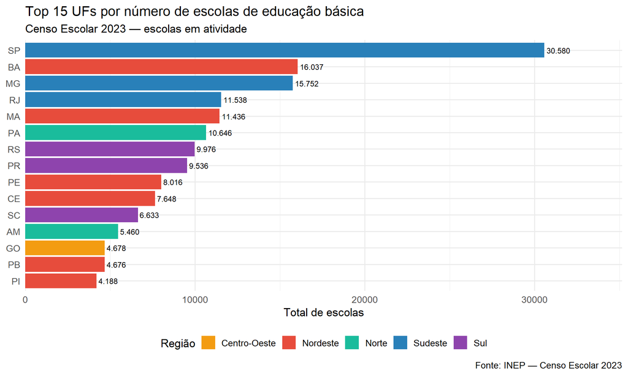

```r
con <- mongo_connect("gold_uf_dependencia")
df_uf <- con$find()

# Top 15 UFs
top_ufs <- df_uf |>
  group_by(SG_UF, NO_REGIAO) |>
  summarise(total = sum(total_escolas), .groups = "drop") |>
  slice_max(total, n = 15)

ggplot(top_ufs, aes(x = reorder(SG_UF, total), y = total, fill = NO_REGIAO)) +
  geom_col() +
  geom_text(aes(label = scales::comma(total, big.mark = ".")),
            hjust = -0.1, size = 3.2) +
  scale_fill_manual(values = cores_regiao) +
  scale_y_continuous(expand = expansion(mult = c(0, 0.15))) +
  coord_flip() +
  labs(
    title    = "Top 15 UFs por número de escolas de educação básica",
    subtitle = "Censo Escolar 2023 — escolas em atividade",
    x        = NULL,
    y        = "Total de escolas",
    fill     = "Região",
    caption  = "Fonte: INEP — Censo Escolar 2023"
  ) +
  theme_minimal(base_size = 13) +
  theme(legend.position = "bottom")
```

**Ver código**

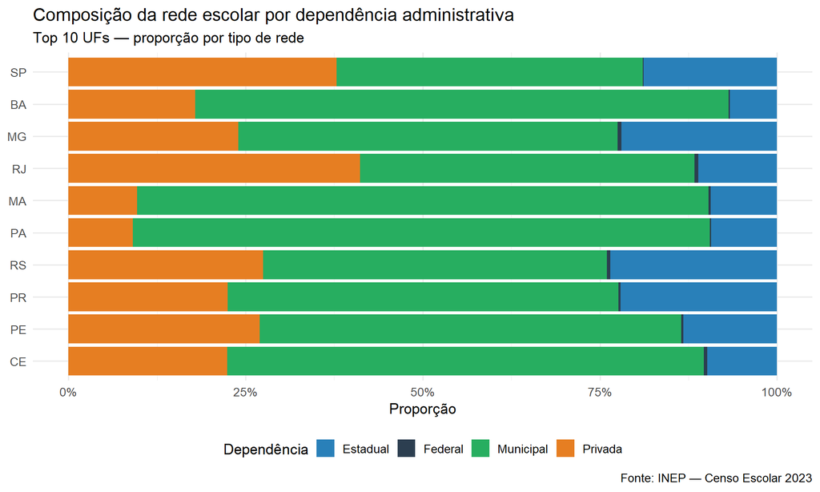

```r
# Composição por dependência — top 10 UFs
top10 <- df_uf |>
  group_by(SG_UF) |>
  summarise(total = sum(total_escolas), .groups = "drop") |>
  slice_max(total, n = 10) |>
  pull(SG_UF)

df_uf |>
  filter(SG_UF %in% top10) |>
  ggplot(aes(x = reorder(SG_UF, total_escolas),
             y = total_escolas, fill = TP_DEPENDENCIA)) +
  geom_col(position = "fill") +
  scale_fill_manual(values = cores_rede) +
  scale_y_continuous(labels = scales::percent) +
  coord_flip() +
  labs(
    title    = "Composição da rede escolar por dependência administrativa",
    subtitle = "Top 10 UFs — proporção por tipo de rede",
    x        = NULL,
    y        = "Proporção",
    fill     = "Dependência",
    caption  = "Fonte: INEP — Censo Escolar 2023"
  ) +
  theme_minimal(base_size = 13) +
  theme(legend.position = "bottom")
```

## 2. Acesso à internet banda larga por UF

**Ver código**

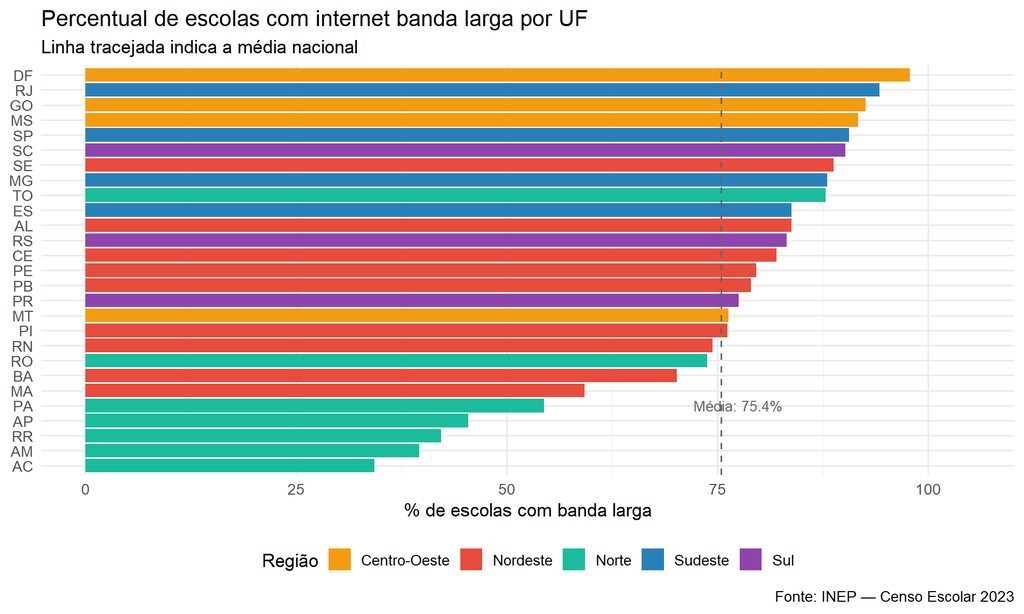

```r
con2 <- mongo_connect("gold_internet_uf")
df_internet <- con2$find()

ggplot(df_internet,
       aes(x = reorder(SG_UF, pct_banda_larga),
           y = pct_banda_larga, fill = NO_REGIAO)) +
  geom_col() +
  geom_hline(yintercept = mean(df_internet$pct_banda_larga),
             linetype = "dashed", color = "gray40") +
  annotate("text", x = 5, y = mean(df_internet$pct_banda_larga) + 2,
           label = paste0("Média: ",
                          round(mean(df_internet$pct_banda_larga), 1), "%"),
           size = 3.5, color = "gray40") +
  scale_fill_manual(values = cores_regiao) +
  scale_y_continuous(limits = c(0, 105)) +
  coord_flip() +
  labs(
    title    = "Percentual de escolas com internet banda larga por UF",
    subtitle = "Linha tracejada indica a média nacional",
    x        = NULL,
    y        = "% de escolas com banda larga",
    fill     = "Região",
    caption  = "Fonte: INEP — Censo Escolar 2023"
  ) +
  theme_minimal(base_size = 13) +
  theme(legend.position = "bottom")
```

## 3. Oferta de etapas de ensino por rede

**Ver código**

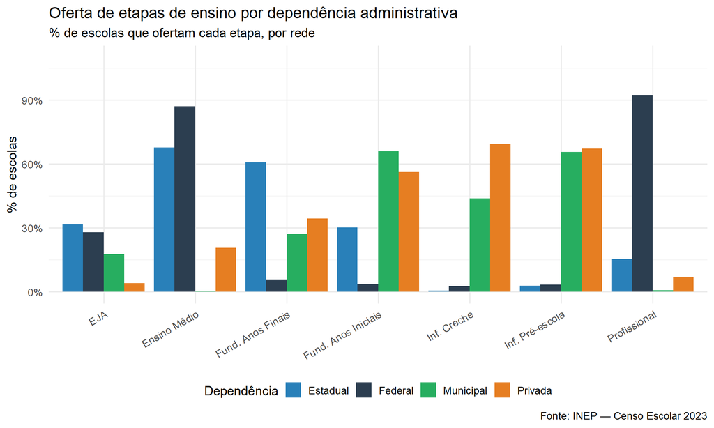

```r
con3 <- mongo_connect("gold_etapas_rede")
df_etapas <- con3$find()

df_etapas_long <- df_etapas |>
  select(TP_DEPENDENCIA, total_escolas,
         infantil_cre, infantil_pre,
         fund_anos_ini, fund_anos_fin,
         ensino_medio, eja, profissional) |>
  pivot_longer(-c(TP_DEPENDENCIA, total_escolas),
               names_to = "etapa", values_to = "escolas") |>
  mutate(
    pct   = round(escolas / total_escolas * 100, 1),
    etapa = recode(etapa,
      "infantil_cre"  = "Inf. Creche",
      "infantil_pre"  = "Inf. Pré-escola",
      "fund_anos_ini" = "Fund. Anos Iniciais",
      "fund_anos_fin" = "Fund. Anos Finais",
      "ensino_medio"  = "Ensino Médio",
      "eja"           = "EJA",
      "profissional"  = "Profissional"
    )
  )

ggplot(df_etapas_long,
       aes(x = etapa, y = pct, fill = TP_DEPENDENCIA)) +
  geom_col(position = "dodge") +
  scale_fill_manual(values = cores_rede) +
  scale_y_continuous(limits = c(0, 110),
                     labels = scales::label_percent(scale = 1)) +
  labs(
    title    = "Oferta de etapas de ensino por dependência administrativa",
    subtitle = "% de escolas que ofertam cada etapa, por rede",
    x        = NULL,
    y        = "% de escolas",
    fill     = "Dependência",
    caption  = "Fonte: INEP — Censo Escolar 2023"
  ) +
  theme_minimal(base_size = 13) +
  theme(
    axis.text.x  = element_text(angle = 30, hjust = 1),
    legend.position = "bottom"
  )
```

## 4. Escolas rurais por UF

**Ver código**

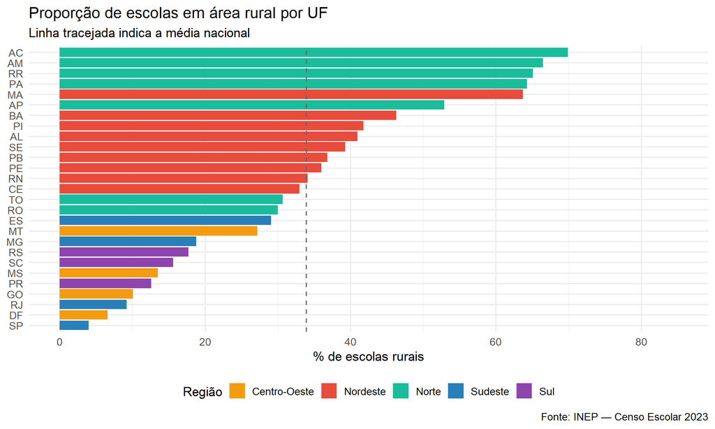

```r
con4 <- mongo_connect("gold_rural_uf")
df_rural <- con4$find()

ggplot(df_rural,
       aes(x = reorder(SG_UF, pct_rural),
           y = pct_rural, fill = NO_REGIAO)) +
  geom_col() +
  geom_hline(yintercept = mean(df_rural$pct_rural),
             linetype = "dashed", color = "gray40") +
  scale_fill_manual(values = cores_regiao) +
  scale_y_continuous(limits = c(0, 85)) +
  coord_flip() +
  labs(
    title    = "Proporção de escolas em área rural por UF",
    subtitle = "Linha tracejada indica a média nacional",
    x        = NULL,
    y        = "% de escolas rurais",
    fill     = "Região",
    caption  = "Fonte: INEP — Censo Escolar 2023"
  ) +
  theme_minimal(base_size = 13) +
  theme(legend.position = "bottom")
```

## 5. Desigualdade de infraestrutura: urbano vs rural

**Ver código**

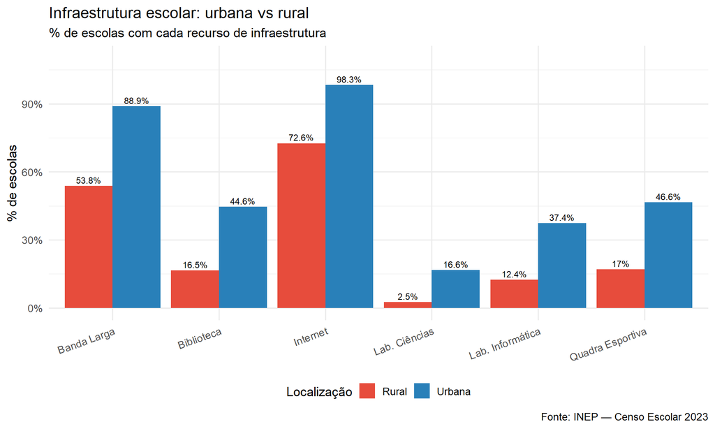

```r
con5 <- mongo_connect("gold_infra_localizacao")
df_infra <- con5$find()

df_infra_long <- df_infra |>
  select(TP_LOCALIZACAO, starts_with("pct_")) |>
  pivot_longer(-TP_LOCALIZACAO,
               names_to = "indicador", values_to = "pct") |>
  mutate(indicador = recode(indicador,
    "pct_biblioteca"   = "Biblioteca",
    "pct_lab_info"     = "Lab. Informática",
    "pct_lab_ciencias" = "Lab. Ciências",
    "pct_quadra"       = "Quadra Esportiva",
    "pct_internet"     = "Internet",
    "pct_banda_larga"  = "Banda Larga"
  ))

ggplot(df_infra_long,
       aes(x = indicador, y = pct, fill = TP_LOCALIZACAO)) +
  geom_col(position = "dodge") +
  geom_text(aes(label = paste0(pct, "%")),
            position = position_dodge(width = 0.9),
            vjust = -0.4, size = 3.2) +
  scale_fill_manual(values = c("Rural" = "#E74C3C", "Urbana" = "#2980B9")) +
  scale_y_continuous(limits = c(0, 110),
                     labels = scales::label_percent(scale = 1)) +
  labs(
    title    = "Infraestrutura escolar: urbana vs rural",
    subtitle = "% de escolas com cada recurso de infraestrutura",
    x        = NULL,
    y        = "% de escolas",
    fill     = "Localização",
    caption  = "Fonte: INEP — Censo Escolar 2023"
  ) +
  theme_minimal(base_size = 13) +
  theme(
    axis.text.x  = element_text(angle = 20, hjust = 1),
    legend.position = "bottom"
  )
```

## Sobre o pipeline

| Camada | Coleção MongoDB | Registros |
| --- | --- | --- |
| Bronze | `bronze_escolas` | 217.625 |
| Silver | `silver_escolas` | 180.230 |
| Gold | 5 coleções agregadas | — |

**Tecnologias:** R 4.6 · MongoDB 7 · Quarto · ggplot2 · mongolite